# Проект 1

Привет! Вот функция:

```r
assemble_df <- function(dir_with_df) {
  files <- list.files(dir_with_df, pattern='*.csv')
  result <- c()
  for (file in files){
    if (is.null(result)){
      result <- read.csv(paste('Data/', file, sep = ''))
    } else {
      s <- read.csv(paste('Data/', file, sep = ''))
      result <- rbind(result, s)
    }
  }
  return(result)
}
```

Насчет данных, вот факторная переменная Sex - не все студенты обозначали половую принадлежность одинаково, поэтому получились такие уровни фактора: 1, 2, 3, male, one, three

Я объединила одинаковые, теперь у моллюсков только три пола: male, female, juvenile

Еще данных есть пропущенные значения:

```
##          Rings            Sex         Length       Diameter         Height
##              1              1              7              5              2
##   Whole_weight Shucked_weight Viscera_weight   Shell_weight
##              1              3              0              2
```

Есть несколько вариантов.

1. Поскольку здесь много данных и мало пропущенных значений, можно просто убрать все строки с пропущенными значениями. Но тогда придется потерять часть информации, ведь вместе с пропущенными значениями будут выброшены и не пропущенные.
2. Заменить пропущенные значения на меры центральной тенденции. Поскольку пол - факторная переменная и там только одно пропущенное значение, в этом случае данную строку лучше убрать. Количество колец - счетная переменная, поэтому для замены пропущенных значений лучше использовать моду. Для всех остальных переменных можно использовать среднее значение.
3. Сначала, как и в первом случае, выбросить все строки с пропущенными значениями. Построить линейные модели по оставшимся значениям для каждой переменной с пропущенными значениями так, значения в каждой переменной можно было бы предсказать через значения остальных. С помощью полученных моделей предсказать пропущенные значения, заменить NA. После этого анализировать уже полные данные.

Мне кажется, третий вариант будет работать лучше всего, но в данном случае я воспользуюсь вторым, потому что это проще и точно сработает. Потом, если останется время, поробую третий. Можно будет сравнить результат.

```
##          Rings            Sex         Length       Diameter         Height
##              0              0              0              0              0
##   Whole_weight Shucked_weight Viscera_weight   Shell_weight
##              0              0              0              0
```

Вот, все пропущенные значения заменены, кроме одной строчки, которую пришлось удалить.

Среднее значение и стандартное отклонение переменной Length для моллюсков разного пола:

```
## # A tibble: 3 x 3
##   Sex       mean     sd
##   <fct>    <dbl>  <dbl>
## 1 male     0.562 0.103
## 2 female   0.579 0.0862
## 3 juvenile 0.428 0.109
```

Среднее значение переменной Height не превышает 0.165 у 76% моллюсков. Значение переменной Length = 0.67 выше чем у 92% от всех наблюдений. Вот структура данных после добавления новой переменной Lenght_z_scores:

```
## 'data.frame':    4176 obs. of  10 variables:
##  $ Rings          : num  18 14 8 12 4 4 12 8 6 8 ...
##  $ Sex            : Factor w/ 3 levels "male","female",..: 2 3 1 1 3 3 1 2 3 2 ...
##  $ Length         : num  0.575 0.385 0.475 0.665 0.28 0.22 0.72 0.55 0.235 0.4 ...
##  $ Diameter       : num  0.45 0.305 0.37 0.525 0.12 0.16 0.565 0.43 0.175 0.3 ...
##  $ Height         : num  0.17 0.095 0.125 0.18 0.075 0.05 0.2 0.15 0.055 0.115 ...
##  $ Whole_weight   : num  1.048 0.252 0.649 1.429 0.117 ...
##  $ Shucked_weight : num  0.3775 0.0915 0.347 0.6715 0.0455 ...
##  $ Viscera_weight : num  0.171 0.055 0.136 0.29 0.029 ...
##  $ Shell_weight   : num  0.385 0.09 0.142 0.4 0.0345 0.015 0.494 0.221 0.018 0.0935 ...
##  $ Lenght_z_scores: num  0.424 -1.158 -0.409 1.174 -2.033 ...
```

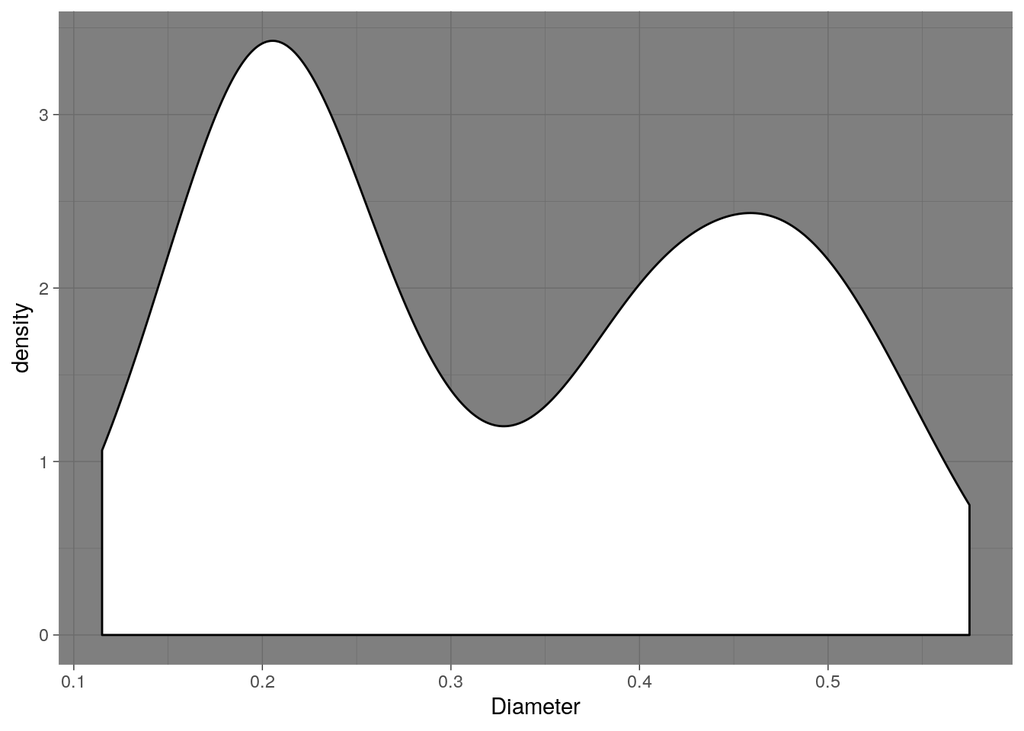

Это частотное распределение диаметров моллюсков с количеством колец 5 и 15. На этом графике видно бимодальное распределение. Сравним же t-критерием их.

```
##
##  Welch Two Sample t-test
##
## data:  Diameter by Rings
## t = -33.636, df = 195.34, p-value < 2.2e-16
## alternative hypothesis: true difference in means is not equal to 0
## 95 percent confidence interval:
##  -0.2599647 -0.2311683
## sample estimates:
##  mean in group 5 mean in group 15
##        0.2106957        0.4562621
```

Похоже, что да, они отличаются. Хорошо.

Теперь посмотрим на переменные Diameter и Whole_weight.

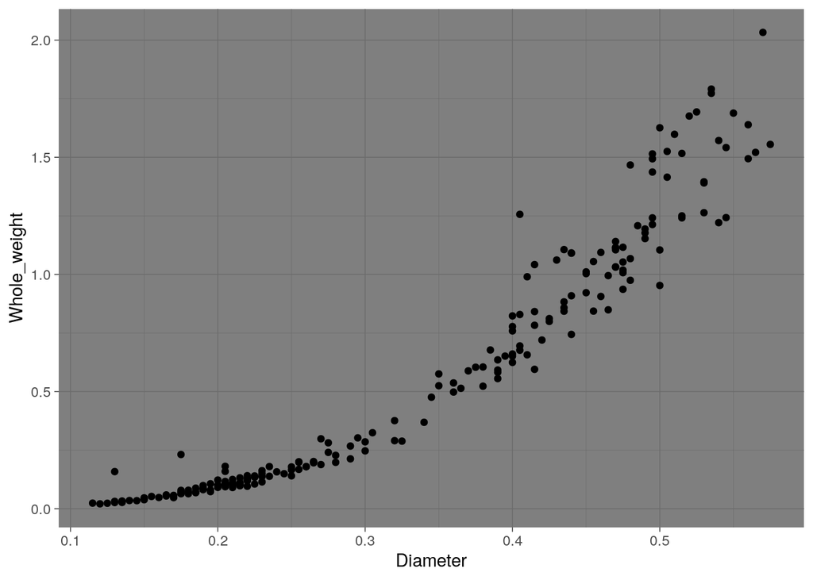

Зависимость между ними не линейная, поэтому линейная модель не могла бы удачно описать взаимосвязь этих переменных. При этом зависимость кубического корня из Whole_weight от переменной Diameter уже больше похожа на линейную.

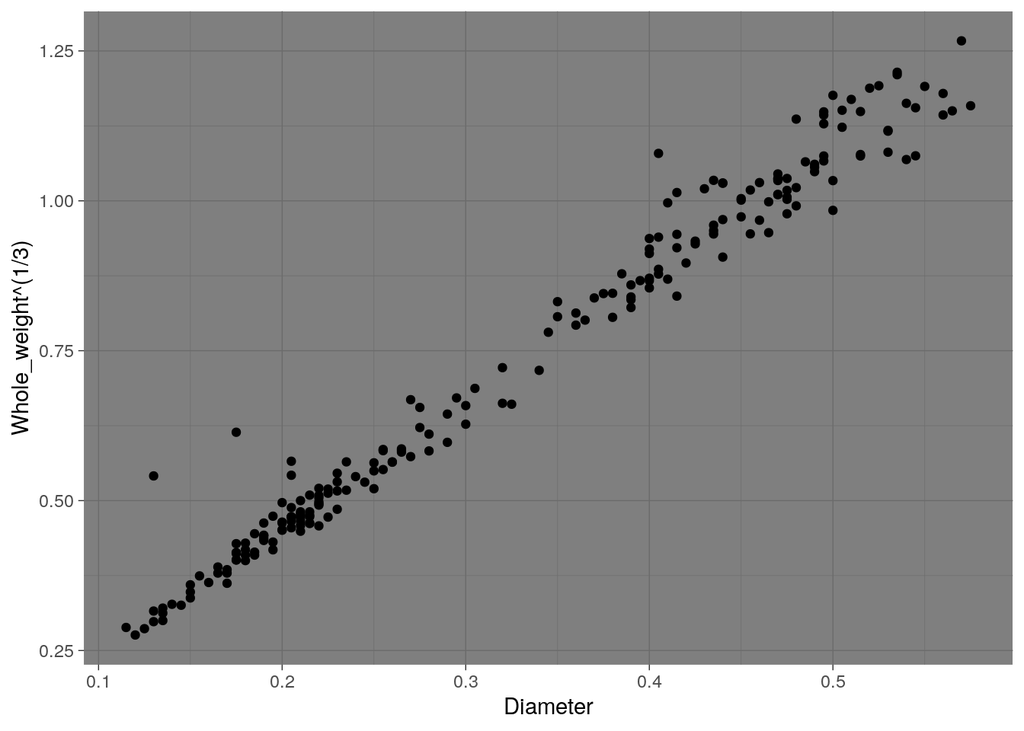

Таким образом, можно построить линейную модель для этих двух переменных, по которой можно будет предсказывать их значения на рассматриваемом участке.